# ISTA 320 FINAL PROJECT

Renee Grambihler

FALL 2021

Data is from TidyTuesday 2021-03-09: https://github.com/rfordatascience/tidytuesday/tree/master/data/2021/2021-03-09

This GitHub repository contains data about movies and the Bechdel Test. The Bechdel Test is meant to be a simple measure of female representation in media (novels, television shows, movies, etc). The criteria for a piece of media passing the Bechdel Test are that there must be at least two, named female characters that talk to each other about something other than a man at least once throughout the piece.

There are two data-sets about movies and the Bechdel Test in the TidyTuesday repository: `raw_bechdel` and `movies`. `raw_bechdel` has movies from 1888-2021 scored from 0-3 based on how much of the Bechdel Test they pass, with (0) being Unscored and (1) having at least two named female characters that (2) talk to each other (3) about something other than a man. `movies` contains data about movies from 1970-2013 including director, IMDB rating, movie rating (e.g. G, PG-13, R, etc.), if the movies pass or fail the Bechdel Test on a binary scale, and more.

```r
# load bechdel datasets from TidyTuesday Repository
tuesdata <- tidytuesdayR::tt_load('2021-03-09')
```

```
## --- Compiling #TidyTuesday Information for 2021-03-09 ----
```

```
## --- There are 2 files available ---
```

```
## --- Starting Download ---
```

```
## --- Download complete ---
```

```r
# separate out raw_bechdel and movies csv's
bechdel_data <- tuesdata$raw_bechdel
movie_data <- tuesdata$movies
```

How has the Bechdel Score in movies changed over time?

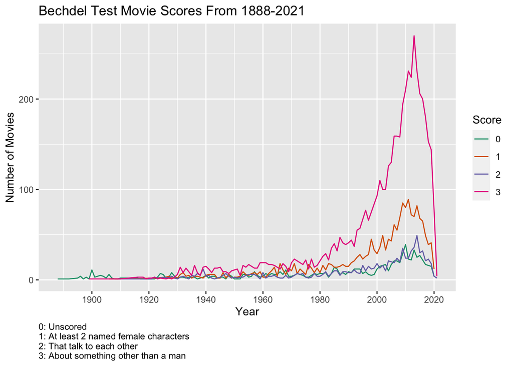

```r
# visualize Bechdel Score over time
bechdel_data %>%
  group_by(year, rating) %>%
  count(rating) %>%
  ggplot(aes(x = year,
             y = n,
             color = as.factor(rating))) +
  geom_line() +
  scale_color_manual(values = brewer.pal(4, "Dark2")) +
  ggtitle("Bechdel Test Movie Scores From 1888-2021") +
  labs(caption = "0: Unscored \n1: At least 2 named female characters \n2: That talk to each other \n3: About something other than a man",
       color = "Score",
       x = "Year",
       y = "Number of Movies") +
  theme(plot.caption = element_text(hjust = 0)) +
  scale_x_continuous(breaks = scales::breaks_pretty(10))
```

How does the IMDB rating (1-10) differ for movies that pass and movies that fail the Bechdel Test?

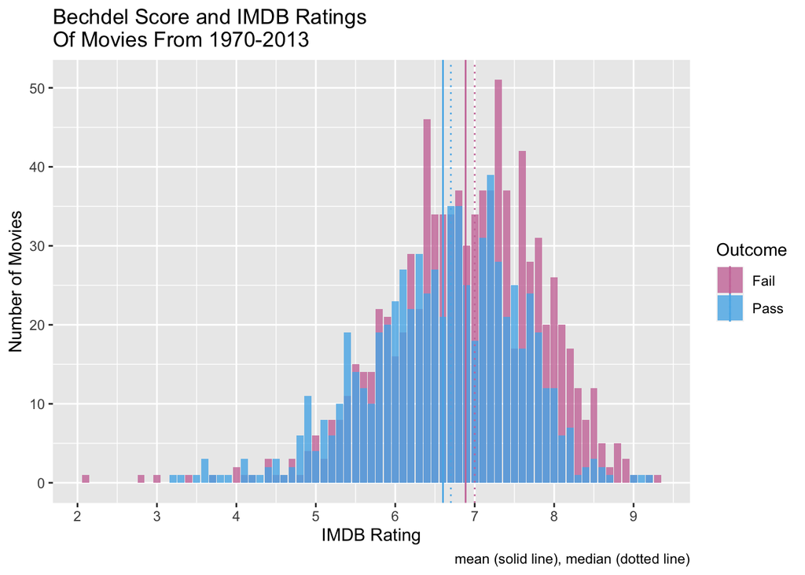

```r
# find mean and median scores by pass/fail
central_tendancy_movie_data <- movie_data %>%
  group_by(binary) %>%
  summarize(mean_imdb_rating = mean(imdb_rating, na.rm = TRUE),
            median_imdb_rating = median(imdb_rating, na.rm = TRUE))

# visualize spread of movie ratings for pass/fail movies
movie_data %>%
  group_by(binary) %>%
  left_join(central_tendancy_movie_data) %>%
  ggplot(aes(x = imdb_rating,
             fill = binary)) +
  geom_bar(position = "identity", alpha=0.8) +
  scale_color_manual(values = c("#CC79A7", "#56B4E9"),
                     labels = c("Fail", "Pass")) +
  scale_fill_manual(values = c("#CC79A7", "#56B4E9"),
                    labels = c("Fail", "Pass")) +
  labs(title = "Bechdel Score and IMDB Ratings \nOf Movies From 1970-2013",
       caption = "mean (solid line), median (dotted line)",
       color = "Outcome",
       fill = "Outcome",
       x = "IMDB Rating",
       y = "Number of Movies") +
  scale_x_continuous(breaks = scales::breaks_pretty(10)) +
  geom_vline(aes(xintercept = mean_imdb_rating,
                 color = binary)) +
  geom_vline(aes(xintercept = median_imdb_rating,
                 color = binary),
                 linetype = "dotted")
```

Is there a significant difference between the IMDB ratings for movies that pass and fail the Bechdel Test?

```r
# create linear model of IMDB Ratings as a function of Binary Pass/Fail
bechdel_rating_model <- movie_data %>%
  lm(formula = imdb_rating ~ binary)
summary(bechdel_rating_model)
```

```
##
## Call:
## lm(formula = imdb_rating ~ binary, data = .)
##
## Residuals:
##     Min      1Q  Median      3Q     Max
## -4.7852 -0.5852  0.0993  0.6993  2.5993
##
## Coefficients:
##             Estimate Std. Error t value Pr(>|t|)
## (Intercept)   6.8852     0.0319 215.854  < 2e-16 ***
## binaryPASS   -0.2845     0.0481  -5.914 4.08e-09 ***
## ---
## Signif. codes:  0 '***' 0.001 '**' 0.01 '*' 0.05 '.' 0.1 ' ' 1
##
## Residual standard error: 0.9527 on 1590 degrees of freedom
##   (202 observations deleted due to missingness)
## Multiple R-squared:  0.02152,    Adjusted R-squared:  0.02091
## F-statistic: 34.98 on 1 and 1590 DF,  p-value: 4.079e-09
```

[figure not shown]

```r
# visualize model
effect("binary", bechdel_rating_model) %>%
  data.frame() %>%
  ggplot(aes(y = reorder(binary, fit),
             x = fit,
             label = round(fit, digits = 3))) +
  geom_errorbar(aes(xmin = lower,
                    xmax = upper),
                width = 0.1) +
  geom_label() +
  labs(y = "",
       x = "Ratings",
       title = "Difference in Mean IMDB Ratings of Movies \nFrom 1970-2013 that Pass and Fail the Bechdel Test")
```